# Stock Assessment Using LBSPR

Selected species of tuna and tuna-like fish in Somalia Water

Author

Rushingisha George, Masumbuko Semba, and Mathew Silas

Published

December 16, 2025

Modified

December 19, 2025

## Introduction

This document provides a step-by-step guide to performing a stock assessment simulation using the **Length-Based Spawning Potential Ratio (LBSPR)** method. LBSPR is a powerful technique for assessing the health of fish stocks, especially in data-limited situations where traditional age-based data is unavailable.

We will first simulate a fish population with known biological and fishery characteristics to understand how the LBSPR model works. This simulation will generate an expected length-frequency distribution, which can later be compared against real-world data collected from fisheries.

## Setting Up the R Environment

**What we’re doing:** Load the R packages needed for the entire analysis. Each package provides specialized functions for different parts of the stock assessment.

**Package purposes:** - **tidyverse**: Data manipulation, filtering, and reshaping - **tidyplots**: Easy, publication-quality plotting - **LBSPR**: Length-based spawning potential ratio analysis - **sizeMat**: Estimating size at sexual maturity - **gt**: Creating professional tables - **TropFishR**: Tropical fisheries stock assessment methods

```r
# Load required libraries
require(tidyverse)
require(tidyplots)
require(LBSPR)
require(sizeMat)
require(gt)
require(TropFishR)
```

# Approach

## Data

**What we’re doing:** Read the fisheries dataset containing length, weight, species, and catch information from a CSV file.

```r
lw = read_csv("lw2.csv")
```

### Model Fish Group: Yellowfin Tuna

**What we’re doing:** Filter the dataset to focus on Yellowfin Tuna (YFT) for this demonstration.

**Why it matters:** Working with a single species ensures we’re analyzing fish with similar biology and behavior.

```r
yft = lw |>
    filter(fish_type_code == 'YFT')
```

### Explore Length-Weight Relationship

**What we’re doing:** Create a scatter plot showing how length and weight relate for Yellowfin Tuna across regions, excluding Berbera and very small fish.

**What to look for:** - A smooth curved relationship indicates normal growth - Outliers might indicate data quality issues - The curve should follow the power-law relationship: Weight ∝ Length³

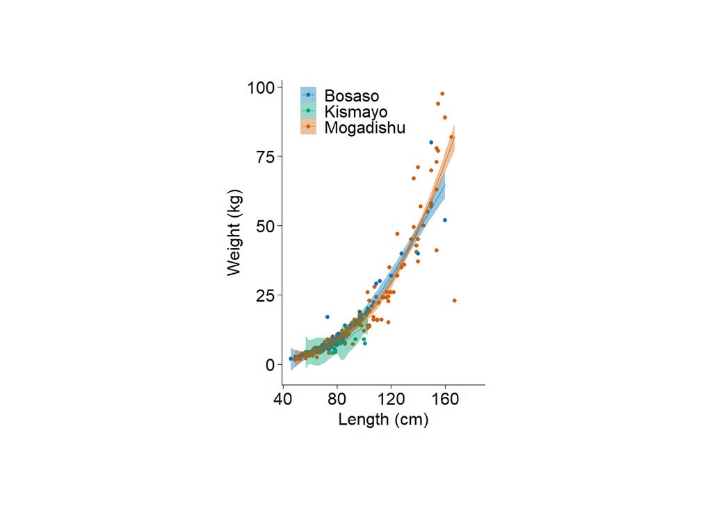

```r
yft |>
  filter(!region %in% c('Berbera') & length_cm > 20) |>
  tidyplot(x = length_cm, y = weight_kg, color = region) |>
  add_data_points() |>
  add_curve_fit() |>
  adjust_size(width = 2, height = 3, unit = 'in') |>
  adjust_font(fontsize = 12) |>
  adjust_legend_position(position = c(.35, .9)) |>
  adjust_x_axis(title = 'Length (cm)') |>
  adjust_y_axis(title = 'Weight (kg)') |>
  remove_legend_title()
```

### Data Quality Filter

**What we’re doing:** Remove problematic data by excluding Berbera region and small fish under 20 cm.

**Why it matters:** Clean data improves assessment reliability and removes potential juveniles with different growth patterns.

```r
yft = lw |>
    filter(fish_type_code == 'YFT' & !region == 'Berbera' & length_cm > 20)
```

### Maturity Classification

**What we’re doing:** Separate fish into two groups—mature and immature—based on their length-weight relationships using linear discriminant analysis.

**Why it matters:** Maturity status is critical for LBSPR because it determines the L50 and L95 parameters that define when fish can reproduce.

```r
## Partitioning with Frequentist regression
classified_yft <- yft |>
  classify_mature(
    varNames = c("length_cm", "weight_kg"),
    varSex = NULL,
    selectSex = NULL,
    method = "ld"
  )
```

```
all individuals were used in the analysis
```

```r
classified_yft
```

```
Number in juvenile group = 272

Number in adult group = 98

--------------------------------------------------------
1) Linear regression for juveniles

Call:
glm(formula = y ~ x, data = juv)

Coefficients:
             Estimate Std. Error t value Pr(>|t|)
(Intercept) -9.184692   0.513034  -17.90   <2e-16 ***
x            0.220284   0.007291   30.21   <2e-16 ***
---
Signif. codes:  0 '***' 0.001 '**' 0.01 '*' 0.05 '.' 0.1 ' ' 1

(Dispersion parameter for gaussian family taken to be 1.638605)

    Null deviance: 1938.03  on 271  degrees of freedom
Residual deviance:  442.42  on 270  degrees of freedom
AIC: 910.22

Number of Fisher Scoring iterations: 2

--------------------------------------------------------
2) Linear regression for adults

Call:
glm(formula = y ~ x, data = adt)

Coefficients:
            Estimate Std. Error t value Pr(>|t|)
(Intercept) -69.6649     5.7059  -12.21   <2e-16 ***
x             0.8608     0.0478   18.01   <2e-16 ***
---
Signif. codes:  0 '***' 0.001 '**' 0.01 '*' 0.05 '.' 0.1 ' ' 1

(Dispersion parameter for gaussian family taken to be 106.3829)

    Null deviance: 44716  on 97  degrees of freedom
Residual deviance: 10213  on 96  degrees of freedom
AIC: 739.46

Number of Fisher Scoring iterations: 2

--------------------------------------------------------
3) Difference between slopes (ANCOVA)
               Estimate Std. Error    t value     Pr(>|t|)
(Intercept)  -9.1846920 2.16246354  -4.247328 2.746951e-05
x             0.2202842 0.03073368   7.167517 4.244089e-12
mature      -60.4802433 3.68591106 -16.408492 9.644949e-46
x:mature      0.6405282 0.03962059  16.166549 9.554434e-45
[1] "slopes are different"
```

### Visualize Maturity Classification

**What we’re doing:** Plot the classified mature and immature fish to visually inspect the separation quality.

**What to look for:** Clear separation between mature (upper right) and immature (lower left) groups indicates good classification accuracy.

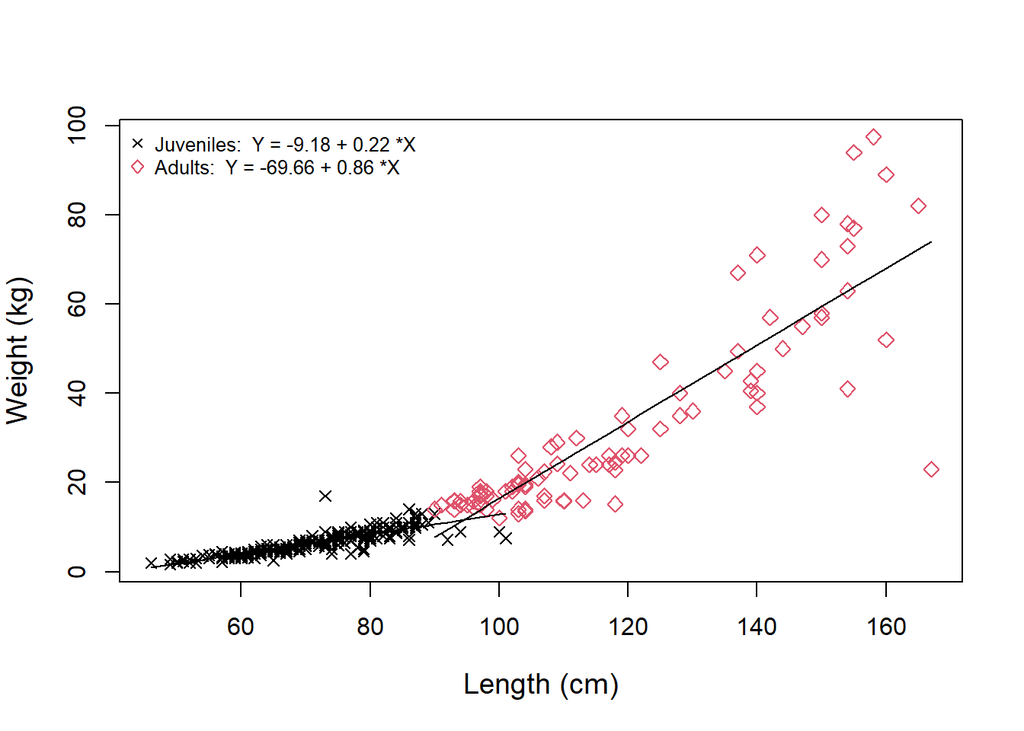

```r
classified_yft |>
  plot(
    xlab = 'Length (cm)',
    ylab = 'Weight (kg)',
    cex.main = 1.5,
    cex.lab = 1.2,
    cex.axis = 1
  )
```

### L50 Estimation

**Why it matters:** L50 and L95 are key biological parameters for LBSPR that define the spawning population.

```r
yft_ogive_fq <- classified_yft |>
  morph_mature(
    method = "fq",
    niter = 1000
)
```

### Display Maturity Curve Parameters

**What we’re doing:** Create a professional table showing the estimated maturity curve parameters.

**Table columns:** - **A & B:** Logistic curve coefficients (intercept and slope) - **L50:** Length (cm) where 50% are mature - **R²:** Goodness of fit (closer to 1.0 is better)

```r
yft_ogive_fq |>
    print() |>
    as.data.frame() |>
    as_tibble() |>
    mutate(Freq = as.numeric(Freq)) |>
    pivot_wider(names_from = Var1 , values_from  = Freq) |>
    gt() |>
    fmt_number(columns = everything(), decimals = 2) |>
    fmt_missing(columns = everything(), missing_text = '-') |>
    cols_label(
        Var2 ~ 'Variables',
        L50 ~ md('L~50~'),
        R2  ~ md('R^2^')
    ) |>
    tab_spanner(columns = c('A', 'B'), label = 'Ogive Parameters') |>
    tab_options(data_row.padding = px(5), table.font.size = '12pt') |>
    cols_width(
        Var2 ~ px(200),
        A ~ px(120),
        B ~ px(70),
        L50 ~ px(70),
        R2 ~ px(70)
    ) |>
    tab_footnote(footnote = 'A for Intercept of the logistic curve.', locations = cells_column_labels(columns = 'A'))|>
    tab_footnote(footnote = 'B for slope of the logistic curve.', locations = cells_column_labels(columns = 'B'))
```

```
formula: Y = 1/1+exp-(A + B*X)
```

[output not shown]

<sup>1</sup> A for Intercept of the logistic curve.  
<sup>2</sup> B for slope of the logistic curve.

### Plot Maturity Ogive

**What we’re doing:** Visualize the maturity curve showing the proportion of mature fish at each length.

**What it shows:** An S-shaped (logistic) curve where: - Below L50: mostly immature fish - Above L50: mostly mature fish - The steepness shows how quickly maturity is reached

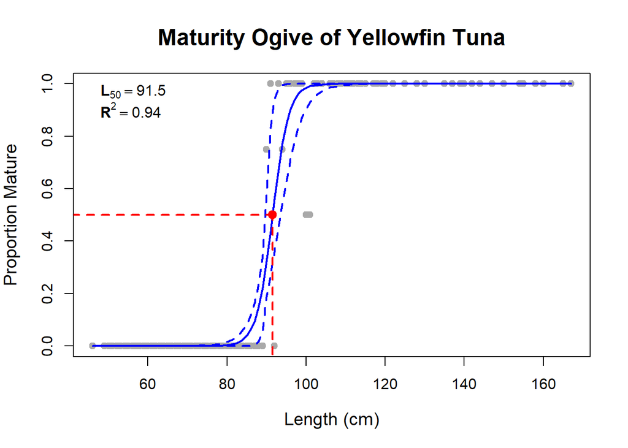

```
Size at morphometric maturity = 91.5
Confidence intervals = 89.8 - 93.4
Rsquare = 0.94
```

```r
yft_ogive_fq |>
    plot(
    main = 'Maturity Ogive of Yellowfin Tuna',
    xlab = 'Length (cm)',
    ylab = 'Proportion Mature',
    cex.main = 1.5,
    cex.lab = 1.2,
    cex.axis = 1,
    onlyOgive = TRUE
)
```

### Prepare Length-Frequency Data

**What we’re doing:** Convert individual fish measurements into binned length-frequency data with smoothing applied.

**Process:** 1. Create length-frequency bins 2. Aggregate data by month 3. Apply moving average (MA = 9) to smooth seasonal variation 4. Apply square root transformation to stabilize variance

**Why it matters:** LBSPR requires data in length-class format; smoothing reduces sampling noise.

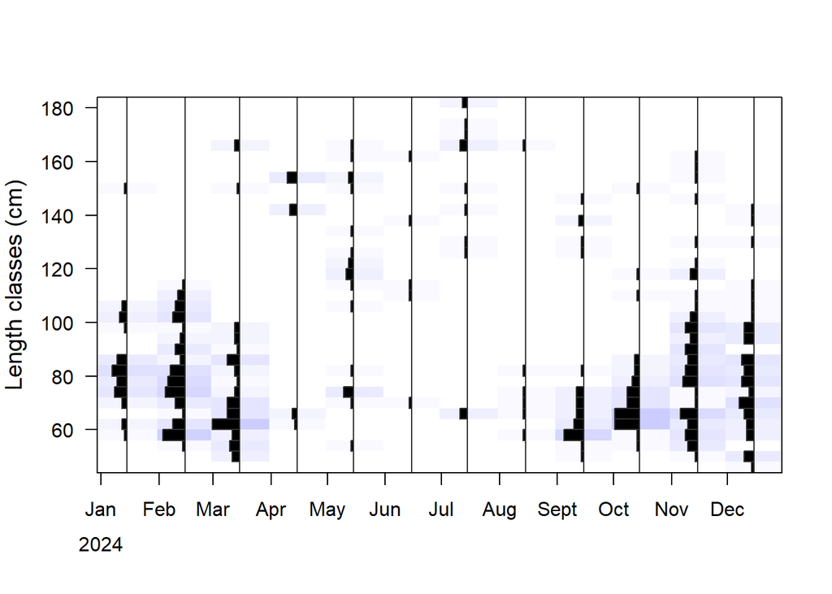

```r
aa = yft |>
   mutate(
    date = lubridate::make_date(year = 2024, month = month(date_dd_mm_yy), day = 15)
    )

aa |>
  TropFishR::lfqCreate(
    Lname = "length_cm",
    Dname = "date",
    bin_size = 2,
    species = "Yellowfin",
    length_unit = "cm",
    aggregate_dates = TRUE
    ) |>
  TropFishR::lfqModify(
    bin_size = 4,
    aggregate = "month",
    vectorise_catch = FALSE
    ) |>
  TropFishR::lfqRestructure(
    MA = 9,
    addl.sqrt = TRUE
    ) |>
    plot(
        Fname = "catch",
        las = 1,
        ylab = 'Length classes (cm)',
        cex.main = 1.5,
        cex.lab = 1.2,
        cex.axis = 1
    )
```

## LBSPR Model

### Create a New LB_pars Object

**What we’re doing:** Create an empty LB_pars object—a special R data structure designed to hold LBSPR model parameters.

**Why it matters:** This object organizes all biological and fishery parameters in a standardized format.

```r
MyPars <- new("LB_pars")
```

### Examine LB_pars Slots

**What we’re doing:** Display all 25 slots (parameter slots) available in the LB_pars object.

**Note:** You don’t need to fill all slots—many have default values. Only minimum parameters are required (see next section).

```r
MyPars |> slotNames()
```

```
 [1] "Species"      "MK"           "M"            "Linf"         "L_units"
 [6] "CVLinf"       "L50"          "L95"          "Walpha"       "Walpha_units"
[11] "Wbeta"        "FecB"         "Steepness"    "Mpow"         "R0"
[16] "SL50"         "SL95"         "MLL"          "sdLegal"      "fDisc"
[21] "FM"           "SPR"          "BinMin"       "BinMax"       "BinWidth"
```

### Populate the LB_pars Object

**What we’re doing:** Fill the LB_pars object with biological and exploitation parameters needed for the LBSPR simulation.

**Minimum required parameters:**

**Biology:** - **Linf:** Von Bertalanffy asymptotic length (maximum theoretical length) - **L50 & L95:** Lengths at 50% and 95% maturity - **M/K:** Natural mortality divided by growth coefficient (describes life history strategy)

**Exploitation:** - **SL50 & SL95:** Lengths at 50% and 95% selectivity by fishing gear - **SPR or F/M:** Either specify Spawning Potential Ratio or Fishing/Natural mortality ratio

**Size classes:** - **BinWidth:** Length interval for size classes (typically 5 cm)

**Example parameters:** These are hypothetical values for demonstration. In a real analysis, these would come from your data analysis (like we did above with Yellowfin).

```r
## Biological parameters
MyPars@Species = 'Yellowfin'
MyPars@Linf <- 100  # Maximum length (cm)
MyPars@L50 <- 66    # Length at 50% maturity (cm)
MyPars@L95 <- 70    # Length at 95% maturity (cm)
MyPars@MK <- 1.5    # M/K ratio (natural mortality / growth rate)

## Exploitation parameters
MyPars@SL50 <- 50   # Length at 50% selectivity (cm)
MyPars@SL95 <- 65   # Length at 95% selectivity (cm)
MyPars@SPR <- 0.4   # Target spawning potential ratio (40% of unfished)
MyPars@BinWidth <- 5

## Size class boundaries
MyPars@BinMax <- 150
MyPars@BinMin <- 0
MyPars@L_units <- "mm"
```

### View the Populated Parameters

**What we’re doing:** Display the LB_pars object to verify all parameters are correctly entered.

```r
MyPars
```

```
An object of class "LB_pars"
Slot "Species":
[1] "Yellowfin"

Slot "MK":
[1] 1.5

Slot "M":
numeric(0)

Slot "Linf":
[1] 100

Slot "L_units":
[1] "mm"

Slot "CVLinf":
[1] 0.1

Slot "L50":
[1] 66

Slot "L95":
[1] 70

Slot "Walpha":
[1] 1e-04

Slot "Walpha_units":
character(0)

Slot "Wbeta":
[1] 3

Slot "FecB":
[1] 3

Slot "Steepness":
[1] 0.7

```

[output cut: 20 more lines]

```

Slot "FM":
numeric(0)

Slot "SPR":
[1] 0.4

Slot "BinMin":
[1] 0

Slot "BinMax":
[1] 150

Slot "BinWidth":
[1] 5
```

### Run the LBSPR Simulation

**What we’re doing:** Execute the LBSPR model to simulate what a fish population would look like with these specific biological and exploitation parameters.

**Output:** An LB_obj object containing simulated population dynamics, size structure, and stock status metrics.

```r
MySim = MyPars |>
  LBSPRsim()
```

### Visualize Full LBSPR Results

**What we’re doing:** Create four diagnostic plots showing: - **Top-left:** Expected catch size structure vs. unfished population - **Top-right:** Maturity and selectivity curves overlaid - **Bottom-left:** Von Bertalanffy growth curve - **Bottom-right:** SPR and yield curves (stock status relative to reference points)

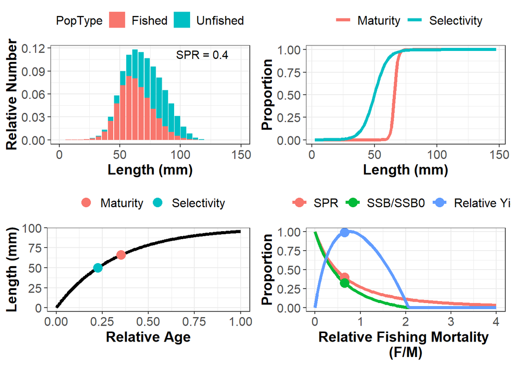

```r
MySim |>
  plotSim()
```

### Plot Length-Frequency Results

**What we’re doing:** Visualize just the expected size structure (length-frequency distribution) from the simulation.

**What to look for:** - The modal length (peak) indicates what size fish dominate the catch - A gap between modal length and maximum length suggests high fishing mortality - Multiple modes may indicate strong recruitment pulses

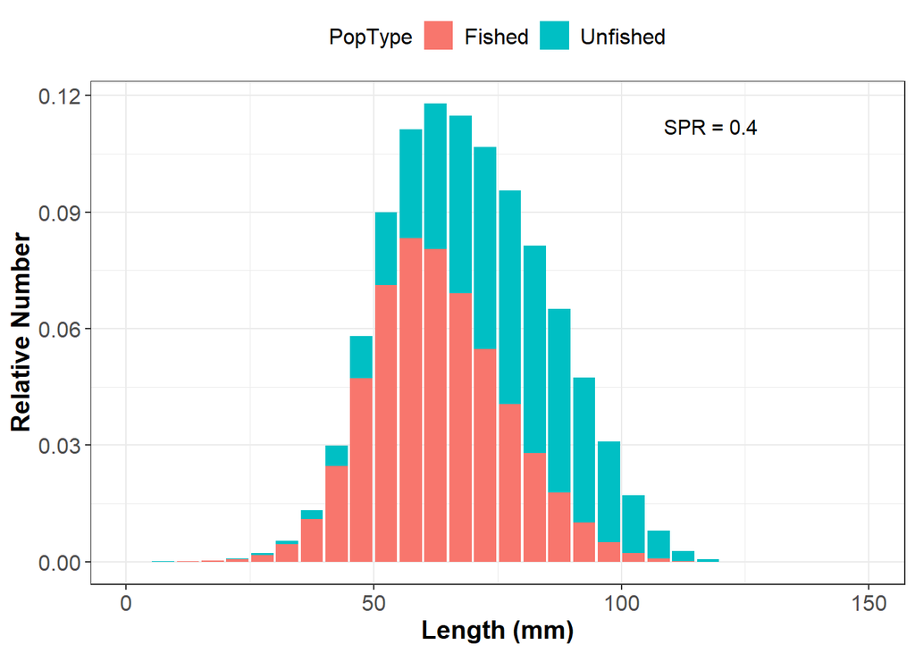

```r
MySim |>
  plotSim(type = "len.freq")
```

### Plot Population Structure

**What we’re doing:** Compare the expected catch composition with the unfished (spawning stock) population structure.

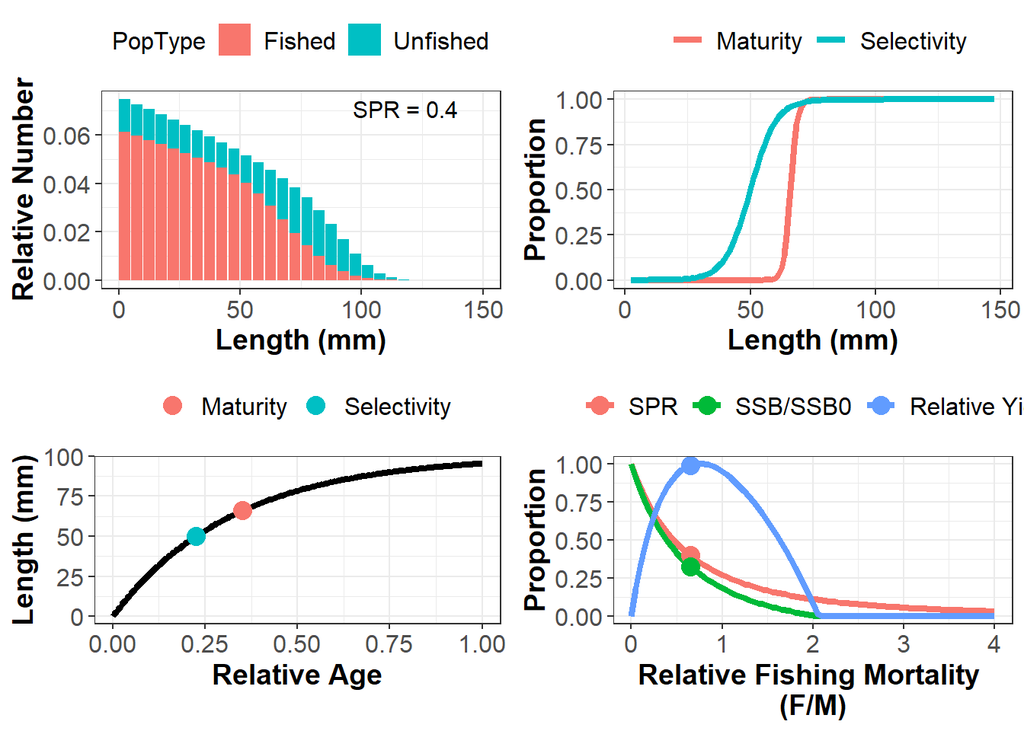

```r
MySim |>
  plotSim(lf.type = "pop")
```